# ESTADISTICA DESCRIPTIVA

# LA FUNCIÓN CROSS TABLE

La función **CrossTable()** Viene en el paquete **gmodels** permite producir (especificando el parámetro prop.chisq=FALSE) un resumen de la tabla de frecuencias absolutas y las tres tablas de frecuencias relativas de dos variables en un formato adecuado para su visualización.

La leyenda Cell Contents explica los contenidos de cada tabla: la frecuencia absoluta, la frecuencia relativa por filas, la frecuencia relativa por columnas y la frecuencia relativa global. Esta función dispone de muchos parámetros que permiten modificar el contenido de las celdas y que podemos consultar en help(CrossTable).

```r
library(gmodels)

sexo=factor(sample(c("H","M"),size = 10,replace = TRUE))
ans=factor(sample(c("S","N"),size = 10,replace = TRUE))
CrossTable(sexo,ans,prop.chisq = FALSE)
```

```
   Cell Contents
|-------------------------|
|                       N |
|           N / Row Total |
|           N / Col Total |
|         N / Table Total |
|-------------------------|


Total Observations in Table:  10


             | ans
        sexo |         N |         S | Row Total |
-------------|-----------|-----------|-----------|
           H |         3 |         2 |         5 |
             |     0.600 |     0.400 |     0.500 |
             |     0.500 |     0.500 |           |
             |     0.300 |     0.200 |           |
-------------|-----------|-----------|-----------|
           M |         3 |         2 |         5 |
             |     0.600 |     0.400 |     0.500 |
             |     0.500 |     0.500 |           |
             |     0.300 |     0.200 |           |
-------------|-----------|-----------|-----------|
Column Total |         6 |         4 |        10 |
             |     0.600 |     0.400 |           |
-------------|-----------|-----------|-----------|
```

# TABLAS DE CONTINGENCIA BIDIMENSIONAL

Básicamente son matrices con algunos atributos extra. En particular, podemos usar sobre estas tablas la mayoría de las funciones para matrices que tengan sentido para las tablas:

- rowSums() y colSums() se pueden aplicar a una tabla y suman sus filas y sus columnas respectivamente
- Tambien podemos usar sobre una tabla bidimensional (o en general, multidimensional) la función apply() con la misma sintaxis que para matrices.

```r
sexo=sample(c("H","M"),size = 10,replace = TRUE)
respuestas=sample(c("S","N"),size = 10,replace = TRUE)
table(sexo,respuestas)
```

```
    respuestas
sexo N S
   H 3 3
   M 1 3
```

```r
colSums(table(sexo,respuestas))#conteos /absolutas
```

```
N S
4 6
```

```r
rowSums(table(sexo,respuestas))#conteos/ absolutas
```

```
H M
6 4
```

```r
colSums(prop.table(table(sexo,respuestas)))#marginal
```

```
  N   S
0.4 0.6
```

```r
rowSums(prop.table(table(sexo,respuestas)))#marginal
```

```
  H   M
0.6 0.4
```

# SUMAS POR FILAS Y COLUMNAS

```r
tt<-table(sexo,respuestas)#frecuencias absolutas
tt#frecuencias absolitas
```

```
##     respuestas
## sexo N S
##    H 3 3
##    M 1 3
```

```r
prop.table(tt)#frecuencias relativas globales
```

```
##     respuestas
## sexo   N   S
##    H 0.3 0.3
##    M 0.1 0.3
```

```r
prop.table(tt,margin = 1)#frecuencias relativas por sexo
```

```
##     respuestas
## sexo    N    S
##    H 0.50 0.50
##    M 0.25 0.75
```

```r
prop.table(tt,margin = 2)#frecuencias relativas por respuesta
```

```
##     respuestas
## sexo    N    S
##    H 0.75 0.50
##    M 0.25 0.50
```

```r
colSums(tt)#absolutas de respuestas
```

```
## N S
## 4 6
```

```r
rowSums(tt)#absolutas de hombres y mujeres
```

```
## H M
## 6 4
```

```r
colSums(prop.table(tt))#cuantas respuestas si y no
```

```
##   N   S
## 0.4 0.6
```

```r
rowSums(prop.table(tt))#cuantos hombres y cuantos mujeres
```

```
##   H   M
## 0.6 0.4
```

```r
apply(tt,FUN=sum, MARGIN=1)
```

```
## H M
## 6 4
```

# UN EJEMPLO DE ESTADÍSTICA MULTIDIMENSIONAL

Multivariante.

## DATOS MULTIDIMENSIONALES FRECUENCIAS ABSOLUTAS Y RELATIVAS

## EJEMPLO TRIDIMENSIONAL DE FRECUENCIAS ABSOLUTAS

```r
answer=sample(c("SI","NO"),size = 100,replace = TRUE)
sexo=sample(c("H","M"),size = 100,replace = TRUE)
place=sample(c("Sevilla","Barcelona","Valencia","Cobija"),size = 100,replace = TRUE)

table(sexo,answer,place)
```

```
, , place = Barcelona

    answer
sexo NO SI
   H  8 11
   M  2  6

, , place = Cobija

    answer
sexo NO SI
   H  9  4
   M  3  9

, , place = Sevilla

    answer
sexo NO SI
   H  5  4
   M 11  6

, , place = Valencia

    answer
sexo NO SI
   H  7  5
   M  5  5
```

```r
ftable(sexo,answer,place)
```

```
            place Barcelona Cobija Sevilla Valencia
sexo answer
H    NO                   8      9       5        7
     SI                  11      4       4        5
M    NO                   2      3      11        5
     SI                   6      9       6        5
```

```r
ftable(sexo,answer,place,col.vars = c("sexo","answer"))
```

```
          sexo    H     M
          answer NO SI NO SI
place
Barcelona         8 11  2  6
Cobija            9  4  3  9
Sevilla           5  4 11  6
Valencia          7  5  5  5
```

### FILTRAR LAS TABLAS DE FRECUENCIAS ABSOLUTAS

```r
table(sexo,answer,place)["M","SI","Barcelona"]
```

```
[1] 6
```

```r
table(sexo,answer,place)[,"SI","Barcelona"]
```

```
 H  M
11  6
```

## FRECUENCIAS RELATIVAS

```r
prop.table(table(sexo,answer,place))#FRECUENCIAS RELATIVAS GLOBALES
```

```
, , place = Barcelona

    answer
sexo   NO   SI
   H 0.08 0.11
   M 0.02 0.06

, , place = Cobija

    answer
sexo   NO   SI
   H 0.09 0.04
   M 0.03 0.09

, , place = Sevilla

    answer
sexo   NO   SI
   H 0.05 0.04
   M 0.11 0.06

, , place = Valencia

    answer
sexo   NO   SI
   H 0.07 0.05
   M 0.05 0.05
```

```r
prop.table(table(sexo,answer,place),margin = 3)# FRECUENCIAS RELATIVA MARGINAL POR REGION
```

```
, , place = Barcelona

    answer
sexo         NO         SI
   H 0.29629630 0.40740741
   M 0.07407407 0.22222222

, , place = Cobija

    answer
sexo         NO         SI
   H 0.36000000 0.16000000
   M 0.12000000 0.36000000

, , place = Sevilla

    answer
sexo         NO         SI
   H 0.19230769 0.15384615
   M 0.42307692 0.23076923

, , place = Valencia

    answer
sexo         NO         SI
   H 0.31818182 0.22727273
   M 0.22727273 0.22727273
```

```r
prop.table(table(sexo,answer,place),margin=c(1,3))#FRECUENCIAS RELATIVA MARGINAL POR SEXO Y PAIS
```

```
, , place = Barcelona

    answer
sexo        NO        SI
   H 0.4210526 0.5789474
   M 0.2500000 0.7500000

, , place = Cobija

    answer
sexo        NO        SI
   H 0.6923077 0.3076923
   M 0.2500000 0.7500000

, , place = Sevilla

    answer
sexo        NO        SI
   H 0.5555556 0.4444444
   M 0.6470588 0.3529412

, , place = Valencia

    answer
sexo        NO        SI
   H 0.5833333 0.4166667
   M 0.5000000 0.5000000
```

```r
ftable(prop.table(table(sexo,answer,place)))
```

```
            place Barcelona Cobija Sevilla Valencia
sexo answer
H    NO                0.08   0.09    0.05     0.07
     SI                0.11   0.04    0.04     0.05
M    NO                0.02   0.03    0.11     0.05
     SI                0.06   0.09    0.06     0.05
```

# EL CONJUNTO DE DATOS HairEyeColor

No es un dataframe sino un conjunto de datos de valor agregado

```r
HairEyeColor
```

```
, , Sex = Male

       Eye
Hair    Brown Blue Hazel Green
  Black    32   11    10     3
  Brown    53   50    25    15
  Red      10   10     7     7
  Blond     3   30     5     8

, , Sex = Female

       Eye
Hair    Brown Blue Hazel Green
  Black    36    9     5     2
  Brown    66   34    29    14
  Red      16    7     7     7
  Blond     4   64     5     8
```

```r
prop.table(HairEyeColor,margin = 3)
```

```
, , Sex = Male

       Eye
Hair          Brown        Blue       Hazel       Green
  Black 0.114695341 0.039426523 0.035842294 0.010752688
  Brown 0.189964158 0.179211470 0.089605735 0.053763441
  Red   0.035842294 0.035842294 0.025089606 0.025089606
  Blond 0.010752688 0.107526882 0.017921147 0.028673835

, , Sex = Female

       Eye
Hair          Brown        Blue       Hazel       Green
  Black 0.115015974 0.028753994 0.015974441 0.006389776
  Brown 0.210862620 0.108626198 0.092651757 0.044728435
  Red   0.051118211 0.022364217 0.022364217 0.022364217
  Blond 0.012779553 0.204472843 0.015974441 0.025559105
```

```r
prop.table(HairEyeColor,margin=c(1,2))
```

```
, , Sex = Male

       Eye
Hair        Brown      Blue     Hazel     Green
  Black 0.4705882 0.5500000 0.6666667 0.6000000
  Brown 0.4453782 0.5952381 0.4629630 0.5172414
  Red   0.3846154 0.5882353 0.5000000 0.5000000
  Blond 0.4285714 0.3191489 0.5000000 0.5000000

, , Sex = Female

       Eye
Hair        Brown      Blue     Hazel     Green
  Black 0.5294118 0.4500000 0.3333333 0.4000000
  Brown 0.5546218 0.4047619 0.5370370 0.4827586
  Red   0.6153846 0.4117647 0.5000000 0.5000000
  Blond 0.5714286 0.6808511 0.5000000 0.5000000
```

```r
aperm(HairEyeColor,perm = c("Sex","Hair","Eye"))
```

```
, , Eye = Brown

        Hair
Sex      Black Brown Red Blond
  Male      32    53  10     3
  Female    36    66  16     4

, , Eye = Blue

        Hair
Sex      Black Brown Red Blond
  Male      11    50  10    30
  Female     9    34   7    64

, , Eye = Hazel

        Hair
Sex      Black Brown Red Blond
  Male      10    25   7     5
  Female     5    29   7     5

, , Eye = Green

        Hair
Sex      Black Brown Red Blond
  Male       3    15   7     8
  Female     2    14   7     8
```

```r
#aperm poermite cambiar el orden de las columans y es más facil de leer
```

Aperm facilita la tarea de comprension de la informacion

KABLE permite manejra y mejorar la visualizacion de datos.

```r
library(kableExtra)
kable(HairEyeColor)
```

| Hair | Eye | Sex | Freq |
| --- | --- | --- | --- |
| Black | Brown | Male | 32 |
| Brown | Brown | Male | 53 |
| Red | Brown | Male | 10 |
| Blond | Brown | Male | 3 |
| Black | Blue | Male | 11 |
| Brown | Blue | Male | 50 |
| Red | Blue | Male | 10 |
| Blond | Blue | Male | 30 |
| Black | Hazel | Male | 10 |
| Brown | Hazel | Male | 25 |
| Red | Hazel | Male | 7 |
| Blond | Hazel | Male | 5 |
| Black | Green | Male | 3 |
| Brown | Green | Male | 15 |
| Red | Green | Male | 7 |
| Blond | Green | Male | 8 |
| Black | Brown | Female | 36 |
| Brown | Brown | Female | 66 |
| Red | Brown | Female | 16 |
| Blond | Brown | Female | 4 |
| Black | Blue | Female | 9 |
| Brown | Blue | Female | 34 |
| Red | Blue | Female | 7 |
| Blond | Blue | Female | 64 |
| Black | Hazel | Female | 5 |
| Brown | Hazel | Female | 29 |
| Red | Hazel | Female | 7 |
| Blond | Hazel | Female | 5 |
| Black | Green | Female | 2 |
| Brown | Green | Female | 14 |
| Red | Green | Female | 7 |
| Blond | Green | Female | 8 |

```r
sex=factor(c("H","M","H","M","M","M","H"))
ans=factor(c("S","N","S","S","S","N","N"))
library(xtable)
xtable(table(sex,ans))
```

|  | N | S |
| --- | --- | --- |
| H | 1 | 2 |
| M | 2 | 2 |

# TABLAS A PARTIR DE DATA FRAMES DE VARIABLES CUALITATIVAS

Las instrucciones utilizadas para calcular tablas de frecuencias absolutas a partir de un data frame de variables cualitativas.

```r
varCuali=read.table("r-basic-master/data/EnergyDrink",header = TRUE)
varCuali$estudio=as.factor(varCuali$estudio)
varCuali$bebe=as.factor(varCuali$bebe)
varCuali$sexo=as.factor(varCuali$sexo)
str(varCuali)
```

```
'data.frame':   122 obs. of  3 variables:
 $ estudio: Factor w/ 4 levels "Industriales",..: 2 3 1 2 1 3 2 1 2 2 ...
 $ bebe   : Factor w/ 2 levels "No","Si": 1 1 2 2 1 1 2 1 1 1 ...
 $ sexo   : Factor w/ 2 levels "Hombre","Mujer": 2 1 2 1 2 2 1 1 1 1 ...
```

```r
head(varCuali,3)
```

|  | estudio | bebe | sexo |
| --- | --- | --- | --- |
| 1 | Informatica | No | Mujer |
| 2 | Mates | No | Hombre |
| 3 | Industriales | Si | Mujer |

```r
summary(varCuali)
```

```
         estudio   bebe        sexo
 Industriales:37   No:97   Hombre:83
 Informatica :53   Si:25   Mujer :39
 Mates       :16
 Telematica  :16
```

**summary** se aplica a un dataframe para conocer las varibales cualitativas que tiene a modo de resumen.

## CALCULO DE TABLAS DE VARIABLES CUALITATIVAS EN UN SOLO PASO

```r
apply(varCuali, MARGIN=2, FUN=table)#RECUERDA QUE PARA APLICAR EL APPLY POR COLUMNAS MARGIN=2
```

```
$estudio

Industriales  Informatica        Mates   Telematica
          37           53           16           16

$bebe

No Si
97 25

$sexo

Hombre  Mujer
    83     39
```

```r
apply(varCuali, MARGIN=2, FUN=table)$sexo
```

```
Hombre  Mujer
    83     39
```

```r
table(varCuali$sexo)
```

```
Hombre  Mujer
    83     39
```

Si aplicamos la funcion **table()** a un dataframe de variables cualitativas, obtenemos su tabla de frecuencias absolutas, con las variables ordenadas tal como aparecen en el dataframe.

```r
table(varCuali)
```

```
, , sexo = Hombre

              bebe
estudio        No Si
  Industriales 19  6
  Informatica  30  7
  Mates         8  1
  Telematica   10  2

, , sexo = Mujer

              bebe
estudio        No Si
  Industriales 10  2
  Informatica  11  5
  Mates         6  1
  Telematica    3  1
```

Tabien se puede aplciar la funcion table a columans especificas y quedarse con esa información.

```r
table(varCuali[c(1,3)])
```

```
              sexo
estudio        Hombre Mujer
  Industriales     25    12
  Informatica      37    16
  Mates             9     7
  Telematica       12     4
```

Para sacar una tabla de frecuencias completa se puede usar la funcion **ftable()**, que produce una misma tabla de frecuencias eprop en formato plano.

```r
ftable(varCuali)
```

```
                  sexo Hombre Mujer
estudio      bebe
Industriales No            19    10
             Si             6     2
Informatica  No            30    11
             Si             7     5
Mates        No             8     6
             Si             1     1
Telematica   No            10     3
             Si             2     1
```

# DIAGRAMAS DE BARRAS

Los diagramas de barras son los graficos mas usados para representar variables cualitativas, mismo que contiene una barra por cada variable cualitativa con su frecuencia.

La manera mas sencilla de dibujar un diagrama de barras de las frecuencias absolutas o relativas de una variable cualitativa es usando la instrucción barplot() aplicada a la tabla correspondiente.

El argumento de la funcion **barplot()** debe ser una tabla, y se ha de aplicar al resultado de **table()** o de **prop.table()**, nunca al vector de datos original.

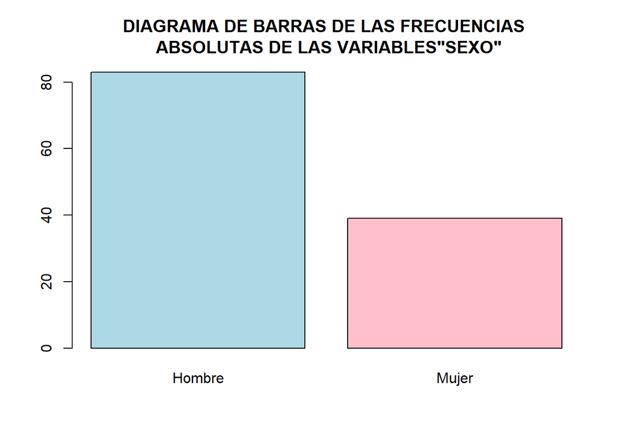

```r
barplot(table(varCuali$sexo),col=c("lightblue","pink"),main="DIAGRAMA DE BARRAS DE LAS FRECUENCIAS \n ABSOLUTAS DE LAS VARIABLES\"SEXO\"")
```

# PARA C0OLOCAR DOS GRAFICOS A UN LADO DE OTRO

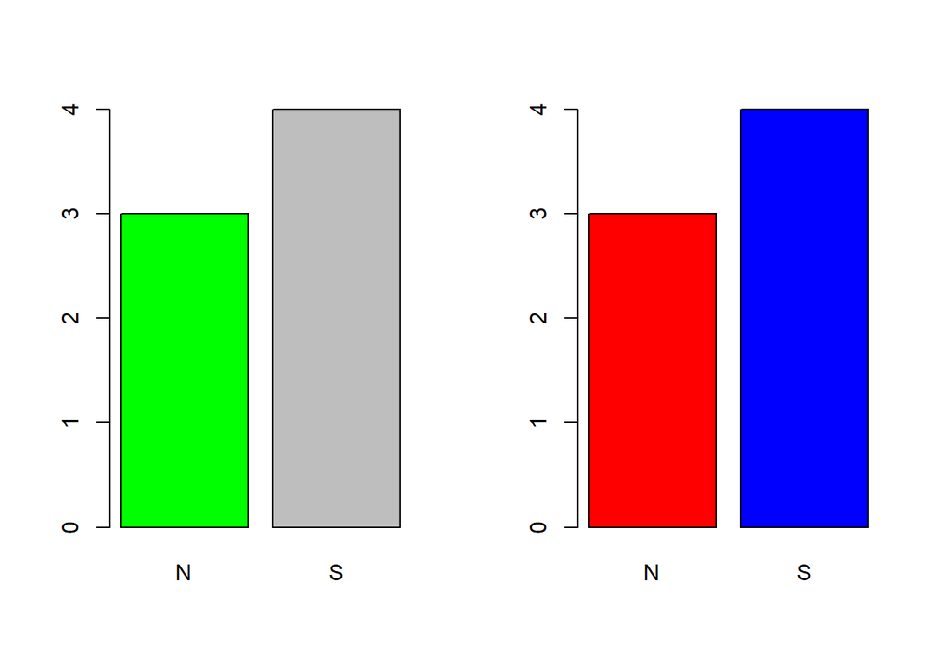

```r
par(mfrow=c(1,2))
barplot(table(ans),col = c("green","gray"))
barplot(table(ans),col = c("red","blue"))
```

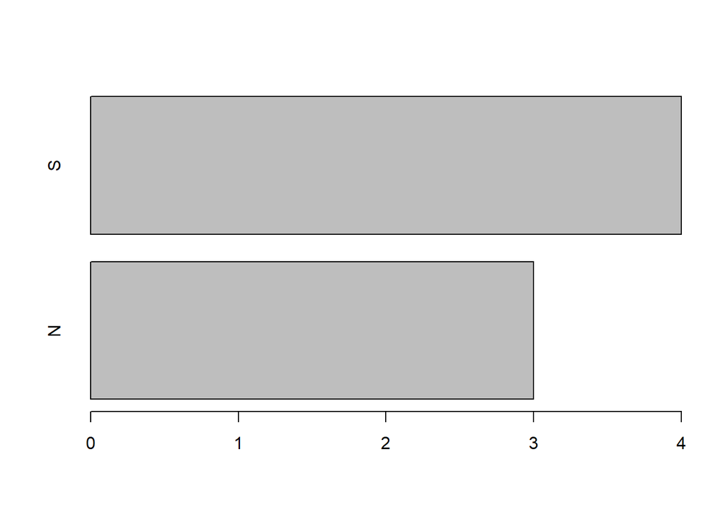

```r
barplot(table(ans),horiz=TRUE)
```

Barplot se ´puede aplicar a tablas bidimensionales

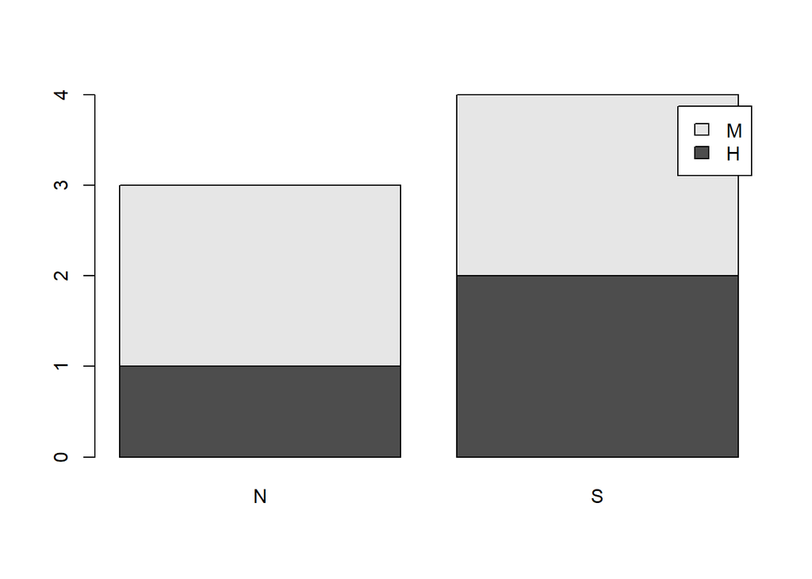

```r
barplot(table(sex,ans),legend.text = TRUE)
```

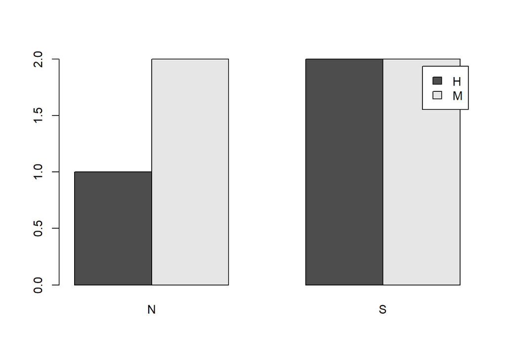

```r
barplot(table(sex,ans),legend.text = TRUE,beside = TRUE)
```

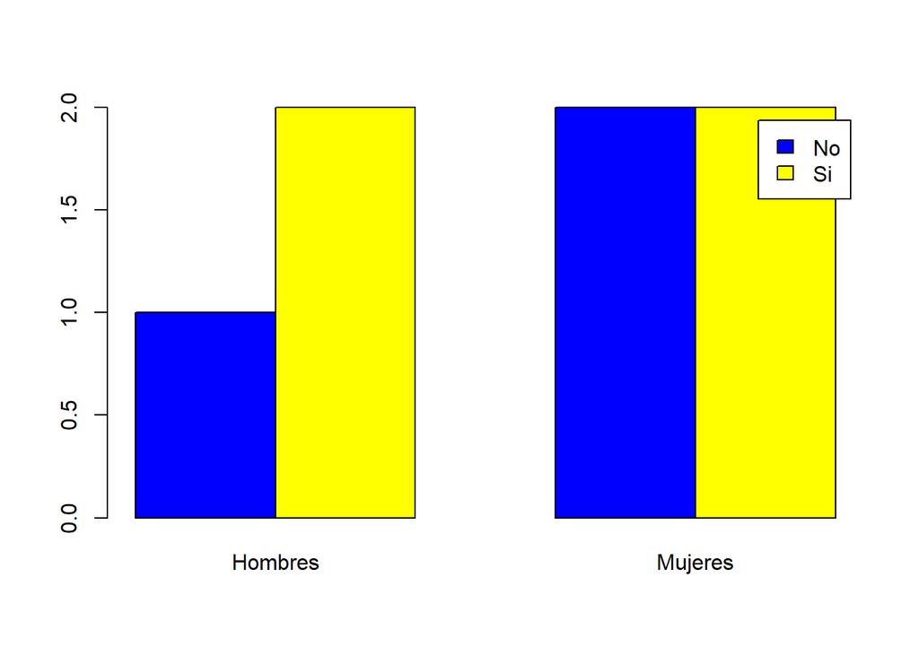

```r
barplot(table(ans,sex),legend.text = c("No","Si"),beside = TRUE,names=c("Hombres","Mujeres"),
        col=c("blue","yellow"))
```

El gráfico más popular y más usado para datos cualitativos es el diagrama de barras, en segundo lugar es el diagrama de pastel.

## DIAGRAMA DE PASTEL

Diagrama de pastel o diagrama circular, se usa para variables cualitativas, se representan los niveles de una variable cualitativa como sectores circulares de un circulo, de manera que el angulo de cada sector es proporcional a la frecuencia del nivel al que corresponde.

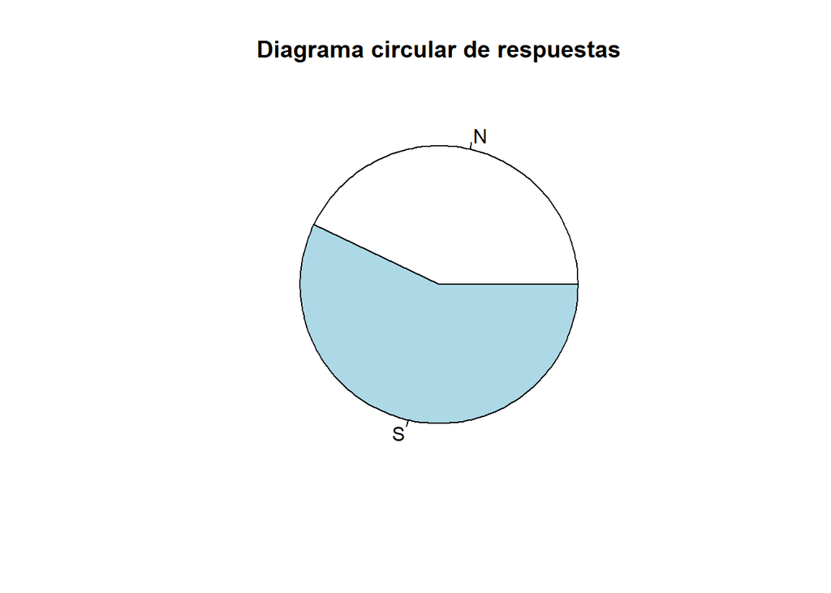

```r
pie(table(ans),main ="Diagrama circular de respuestas")
```

No es recomendable usar un diagrama de pastel.

## DIAGRAMA DE MOSAICO

Se obtienen sustituyendo cada entrada de la tabla de frecuencias por una region rectangular de área proporcional a su valor.

Un gráfico de mosaico se obtiene aplocando plot a la tabla o mosaicplot (mosaicplot se puede aplicar a matrices).

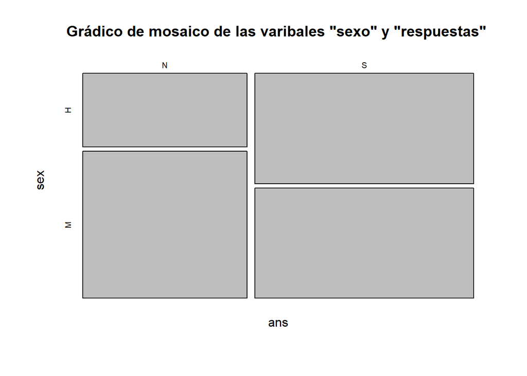

```r
plot(table(ans,sex),main="Grádico de mosaico de las varibales \"sexo\" y \"respuestas\" ")
```

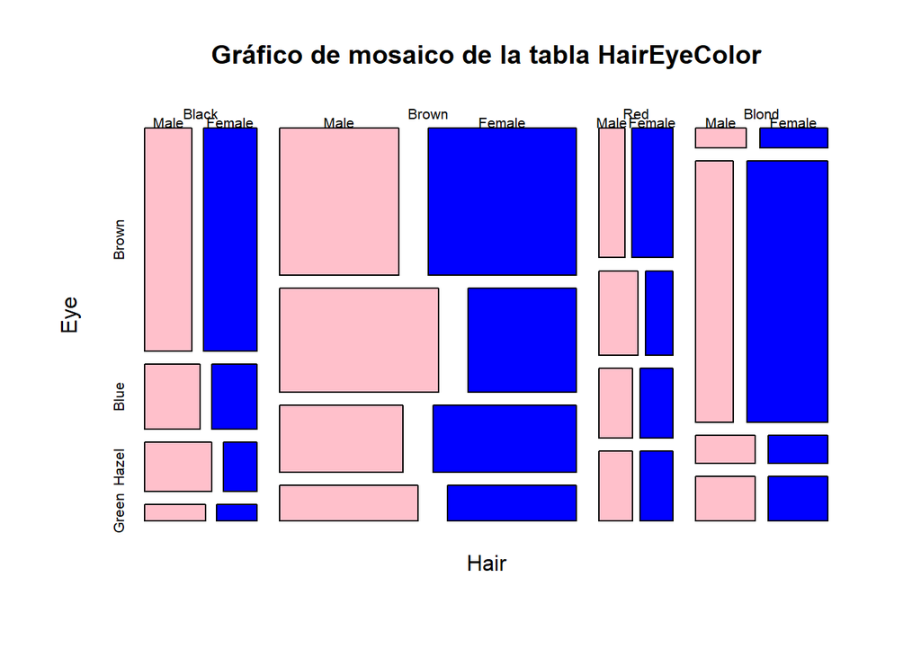

```r
plot(HairEyeColor,main="Gráfico de mosaico de la tabla HairEyeColor",col=c("pink","blue"))
```

Los paquetes **vcd** y **vcdExtra** incluyen otras funciones que producen representaciones gráficas interesantes de tablas tridimensinales. * La función **cotabplot** de **vcd** produce un diagrama de mosaico para cada nivel de la tercera variable * La función **mosaic3d** de **vcdExtra** produce un diagrama de mosaico tridimensional en una ventana de una aplicación para gráficos 3D interactivos.

```r
library(vcd)
```

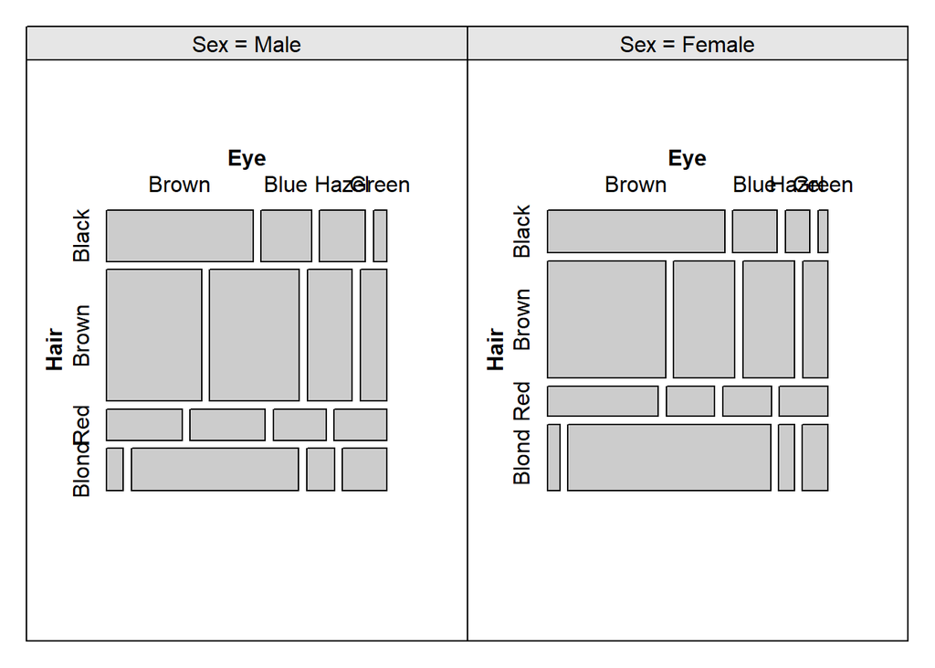

```r
cotabplot(HairEyeColor)
```

```r
library(vcdExtra)
mosaic3d(HairEyeColor,type = "expected",box=TRUE,col=c("blue","pink"))
```

# EJERCICIO COMPLETO DE DATOS CUALITATIVOS

Vamos a llevar a cabo un análisis completo de un ejemplo con lo que hemos aprendido en esta lección y aprovecharemos para aprender algo nuevo.

El objeto de datos **HairEyeColor** que lleva predefinido R es una tabla de frecuencias absolutas de tres variables cualitativas: Color de cabello, color de los ojos y sexo.

Vamos a extraer de esta tabla una tabla bidimensional de frecuencias absolutas de als variables Eye y Hair sin distinguir segun el sexo. La manera mas sencilla de obtener esta tabla es sumando las subtablas de frecuencias para hombres y mujeres, y aplicando **as.table()** al resultado para transformarlo en una table por sino lo es.

## JUNTAR COLOR DE OJOS Y DE PELO SIN DISTINGUIR POR SEXO

```r
male<-HairEyeColor[,,"Male"]
female<-HairEyeColor[,,"Female"]
dataUnida<-as.table(male+female)
```

## MANIPULACIÓN DE DATOS

```r
dimnames(dataUnida)#ACCEDER A LOS VALORES DE LA MISMA
```

```
$Hair
[1] "Black" "Brown" "Red"   "Blond"

$Eye
[1] "Brown" "Blue"  "Hazel" "Green"
```

```r
dimnames(dataUnida)=list(
  Pelo=c("Negro","Cafe","Rojo","Rubio"),
  Ojos=c("Café","Azules","Avellanado","Verde")
)#CAMBIO DE NOMBRES A LA TABLA
```

## DIBUJANDO EL DIAGRAMA DE MOSAICO PARA VISUALIZAR GRAFICAMENTE SUS ENTRADAS.

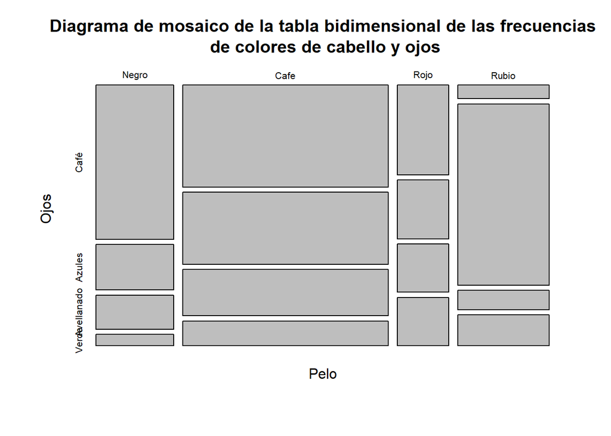

```r
plot(dataUnida,main="Diagrama de mosaico de la tabla bidimensional de las frecuencias\n de colores de cabello y ojos")
```

## DATOS NUMÉRICOS CALCULANDO EL NUMERO DE INDIVIDUOPS QUE HAY REPRESENTADOS EN LA TABLA

```r
sum(dataUnida)
```

```
[1] 592
```

## TABLA DE FRECUENCIA ABSOLUTA Y RELATIVA DE CADA VARIABLE

### TABLA DE FRECUENCIAS ABSOLUTAS DE COLOR DE OJOS

```r
colSums(dataUnida)->absColOjo
absColOjo
```

```
      Café     Azules Avellanado      Verde
       220        215         93         64
```

### TABLA DE FRECUENCIAS ABSOLUTAS DE COLOR DE PELO

```r
rowSums(dataUnida)->absColPel
absColPel
```

```
Negro  Cafe  Rojo Rubio
  108   286    71   127
```

### TABLA DE FRECUENCIAS RELATIVAS DE COLOR DE OJOS

```r
round(colSums(prop.table(dataUnida)),3)->relColOjo
relColOjo
```

```
      Café     Azules Avellanado      Verde
     0.372      0.363      0.157      0.108
```

### TABLA DE FRECUENCIAS RELATIVAS DE COLOR DE PELO

```r
round(rowSums(prop.table(dataUnida)),3)->relColPel
relColPel
```

```
Negro  Cafe  Rojo Rubio
0.182 0.483 0.120 0.215
```

### REPRESENTANDO GRÁFICAMENTE EN DIAGRAMA DE BARRAS

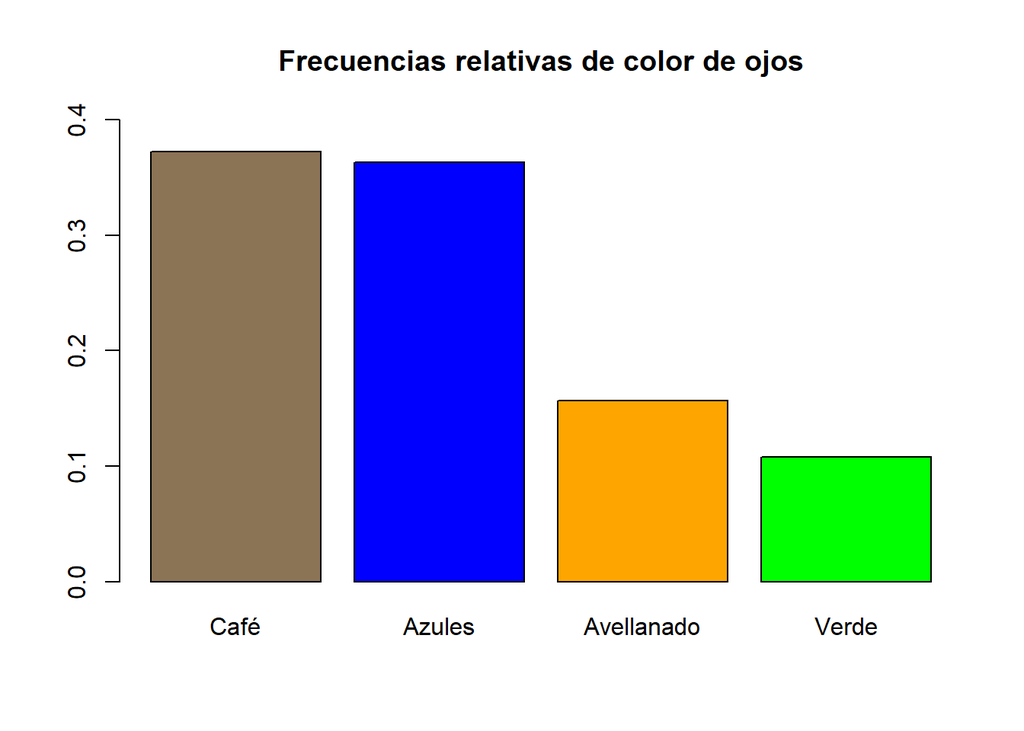

```r
barplot(relColOjo,col=c("Burlywood4","Blue","Orange","Green"),ylim=c(0,0.4),main="Frecuencias relativas de color de ojos")
```

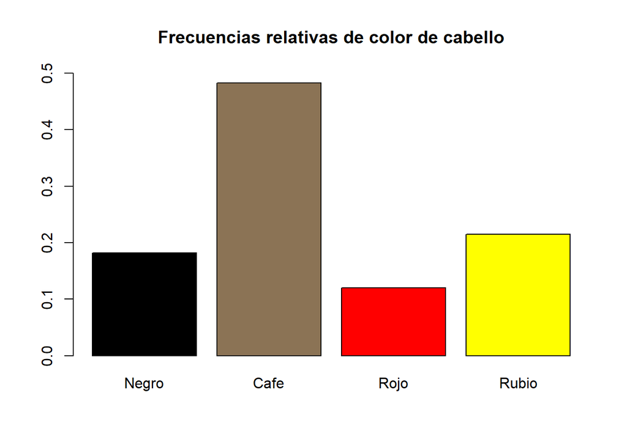

```r
barplot(relColPel,col = c("Black","Burlywood4","Red","Yellow"),ylim = c(0,0.5),main="Frecuencias relativas de color de cabello")
```

## CALCULO DE TABLA DE FRECUENCIAS RELATIVAS GLOBALES

```r
round(prop.table(dataUnida),3)
```

```
       Ojos
Pelo     Café Azules Avellanado Verde
  Negro 0.115  0.034      0.025 0.008
  Cafe  0.201  0.142      0.091 0.049
  Rojo  0.044  0.029      0.024 0.024
  Rubio 0.012  0.159      0.017 0.027
```

## CALCULO DE LA TABLA MARGINAL POR FILA

```r
round(prop.table(dataUnida,margin = c(1)),3)->marginalFila
marginalFila
```

```
       Ojos
Pelo     Café Azules Avellanado Verde
  Negro 0.630  0.185      0.139 0.046
  Cafe  0.416  0.294      0.189 0.101
  Rojo  0.366  0.239      0.197 0.197
  Rubio 0.055  0.740      0.079 0.126
```

## CALCULO DE TABLA MARGINAL POR COLUMNA

```r
round(prop.table(dataUnida,margin = c(2)),3)->marginalColumna
marginalColumna
```

```
       Ojos
Pelo     Café Azules Avellanado Verde
  Negro 0.309  0.093      0.161 0.078
  Cafe  0.541  0.391      0.581 0.453
  Rojo  0.118  0.079      0.151 0.219
  Rubio 0.032  0.437      0.108 0.250
```

## REPRESENTACIÓN GRÁFICA DE FRECUENCIAS RELATIVAS OBTENIDAS Y CLASIFICADAS

[figure not shown]

```r
barplot(marginalFila,legend.text = TRUE,col=c("Black","Burlywood4","Red","Yellow"),beside = TRUE,xlab="Color de Ojos",ylim=c(0,0.8),main="Frecuencias relativas de colores de cabello para cada color de ojos")
```

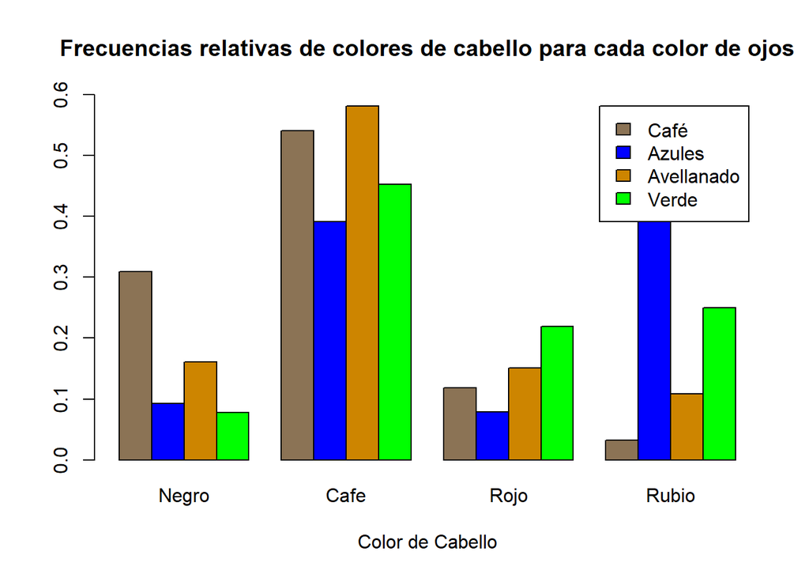

```r
barplot(t(marginalColumna),legend.text = TRUE,col=c("Burlywood4","Blue","Orange3","Green"),beside = TRUE,xlab="Color de Cabello",ylim = c(0,0.6),main = "Frecuencias relativas de colores de cabello para cada color de ojos")
```

Recuerda que se usa la transpuesta dado que se quiere obtener el grafico de barras de la transpuesta para el calculo de frecuencia relativa marginal de cada color de cabello por cada color de ojos.

# TAREA ESTUDIO DE BEBÉS RECIÉN NACIDOS

**Preguntas de esta tarea** 1. Utiliza str() y head() para explorar la estructura, y con help(), mirar el significado de cada variable.

2. Calcula una tabla de frecuencias relativas marginales de los pares (raza de la madre, peso inferior a 2.5 kg o no) que permita ver si la raza de la madre influye en el peso del bebé.
3. Dibuja un diagrama de mosaico de la tabla del ejercicio anterior.
4. Dibuja un diagrama bidimensional de barras, con las barras organizadas en bloques, que permita visualizar la información de los ejercicios anteriores. Aprovecha para nombres adecuados a los bloques, colores a las barras, y añadir una leyenda que explique qué representa cada barra.
5. ¿Se puede obtener alguna conclusión de la tabla y el diagrama de barras anterior? Argumenta tu respuesta
6. Repite los cuatro ejercicios anteriores para los pares (madre fumadora o no, peso inferior a 2.5 kg o no) y para los pares (madre hipertensa o no, peso inferior a 2.5 kg o no.
7. Calcula una tabla de frecuencias relativas marginales de las ternas (raza de la madre, madre fumadora o no, peso inferior a 2.5 kg o no) que permita ver si la raza de la madre y su condición de fumadora o no fumadora influyen en el peso del bebé.
8. Dibuja un diagrama de mosaico de la tabla del ejercicio anterior.

```r
library(MASS)
birthwt
```

|  | low | age | lwt | race | smoke | ptl | ht | ui | ftv | bwt |
| --- | --- | --- | --- | --- | --- | --- | --- | --- | --- | --- |
| 85 | 0 | 19 | 182 | 2 | 0 | 0 | 0 | 1 | 0 | 2523 |
| 86 | 0 | 33 | 155 | 3 | 0 | 0 | 0 | 0 | 3 | 2551 |
| 87 | 0 | 20 | 105 | 1 | 1 | 0 | 0 | 0 | 1 | 2557 |
| 88 | 0 | 21 | 108 | 1 | 1 | 0 | 0 | 1 | 2 | 2594 |
| 89 | 0 | 18 | 107 | 1 | 1 | 0 | 0 | 1 | 0 | 2600 |
| 91 | 0 | 21 | 124 | 3 | 0 | 0 | 0 | 0 | 0 | 2622 |
| 92 | 0 | 22 | 118 | 1 | 0 | 0 | 0 | 0 | 1 | 2637 |
| 93 | 0 | 17 | 103 | 3 | 0 | 0 | 0 | 0 | 1 | 2637 |
| 94 | 0 | 29 | 123 | 1 | 1 | 0 | 0 | 0 | 1 | 2663 |
| 95 | 0 | 26 | 113 | 1 | 1 | 0 | 0 | 0 | 0 | 2665 |

[output cut: 179 more lines]

```r
#INSTRUCCION NUMERO 1
str(birthwt)
```

```
## 'data.frame':    189 obs. of  10 variables:
##  $ low  : int  0 0 0 0 0 0 0 0 0 0 ...
##  $ age  : int  19 33 20 21 18 21 22 17 29 26 ...
##  $ lwt  : int  182 155 105 108 107 124 118 103 123 113 ...
##  $ race : int  2 3 1 1 1 3 1 3 1 1 ...
##  $ smoke: int  0 0 1 1 1 0 0 0 1 1 ...
##  $ ptl  : int  0 0 0 0 0 0 0 0 0 0 ...
##  $ ht   : int  0 0 0 0 0 0 0 0 0 0 ...
##  $ ui   : int  1 0 0 1 1 0 0 0 0 0 ...
##  $ ftv  : int  0 3 1 2 0 0 1 1 1 0 ...
##  $ bwt  : int  2523 2551 2557 2594 2600 2622 2637 2637 2663 2665 ...
```

```r
head(birthwt,5)
```

|  | low | age | lwt | race | smoke | ptl | ht | ui | ftv | bwt |
| --- | --- | --- | --- | --- | --- | --- | --- | --- | --- | --- |
| 85 | 0 | 19 | 182 | 2 | 0 | 0 | 0 | 1 | 0 | 2523 |
| 86 | 0 | 33 | 155 | 3 | 0 | 0 | 0 | 0 | 3 | 2551 |
| 87 | 0 | 20 | 105 | 1 | 1 | 0 | 0 | 0 | 1 | 2557 |
| 88 | 0 | 21 | 108 | 1 | 1 | 0 | 0 | 1 | 2 | 2594 |
| 89 | 0 | 18 | 107 | 1 | 1 | 0 | 0 | 1 | 0 | 2600 |

```r
help("birthwt")
```

```
## starting httpd help server ... done
```

```r
#INSTRUCCION NUMERO 2
relacionRaza_Peso=round(prop.table(table(birthwt$race,birthwt$low),margin = 1),3)
dimnames(relacionRaza_Peso)=list(c("Blanco","Negro","Otro"),c("Mas de 2.5kG","Menos de 2.5kG"))
relacionRaza_Peso
```

```
##        Mas de 2.5kG Menos de 2.5kG
## Blanco        0.760          0.240
## Negro         0.577          0.423
## Otro          0.627          0.373
```

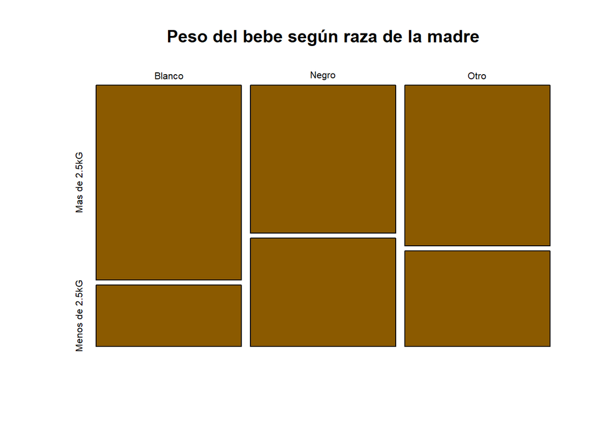

```r
#INTRUCCION NUMERO 3
plot((relacionRaza_Peso),main="Peso del bebe según raza de la madre",col=c("Orange4"))
```

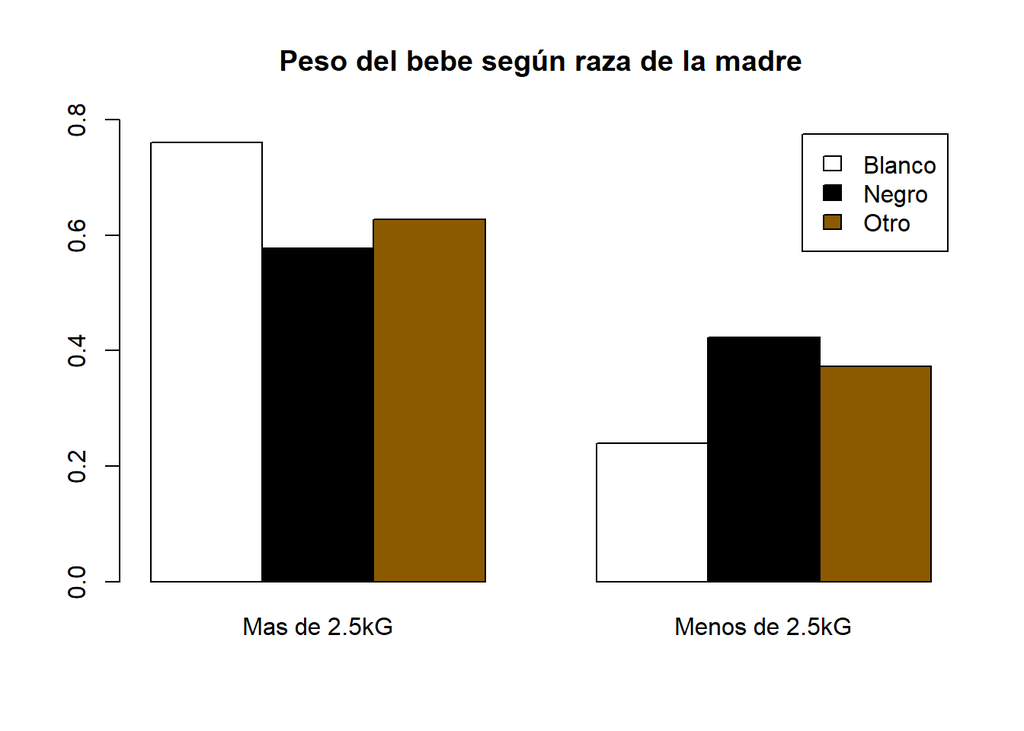

```r
#INSTRUCCIÓN NUMERO 4
barplot(relacionRaza_Peso,main = "Peso del bebe según raza de la madre",beside = TRUE,legend.text = TRUE,col=c("White","Black","Orange4"),ylim = c(0,0.8))
```

```r
#INTRUCCION NUMERO 5
relacionFumadorNo=round(prop.table(table(birthwt$smoke,birthwt$low)),3)
dimnames(relacionFumadorNo)=list(c("No Fuma","Fuma"),c("Más de 2.5kG","Menos de 2.5kG"))
relacionFumadorNo
```

```
##         Más de 2.5kG Menos de 2.5kG
## No Fuma        0.455          0.153
## Fuma           0.233          0.159
```

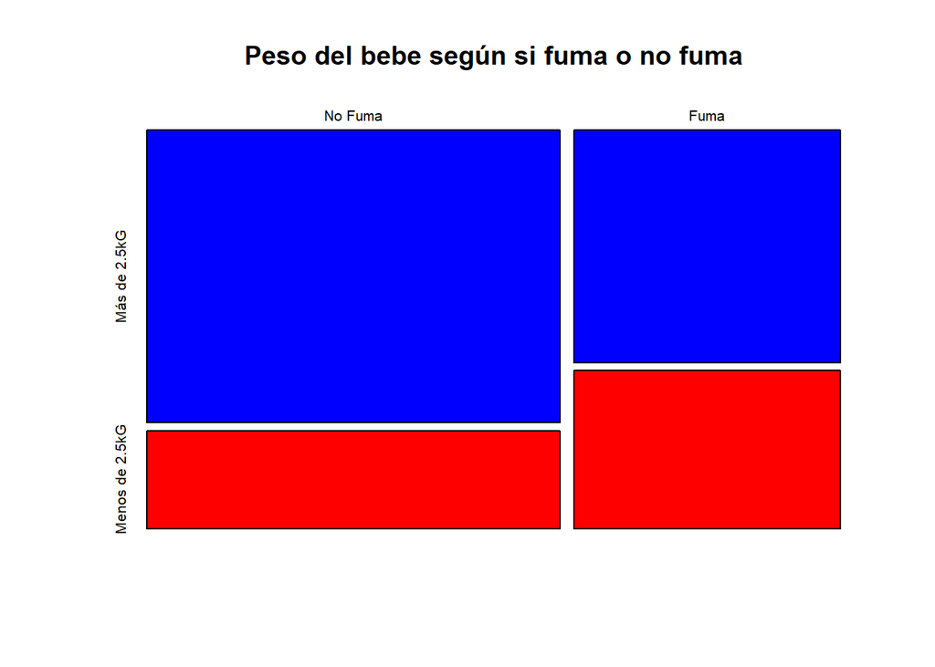

```r
plot(relacionFumadorNo,main="Peso del bebe según si fuma o no fuma",col=c("Blue","Red"))
```

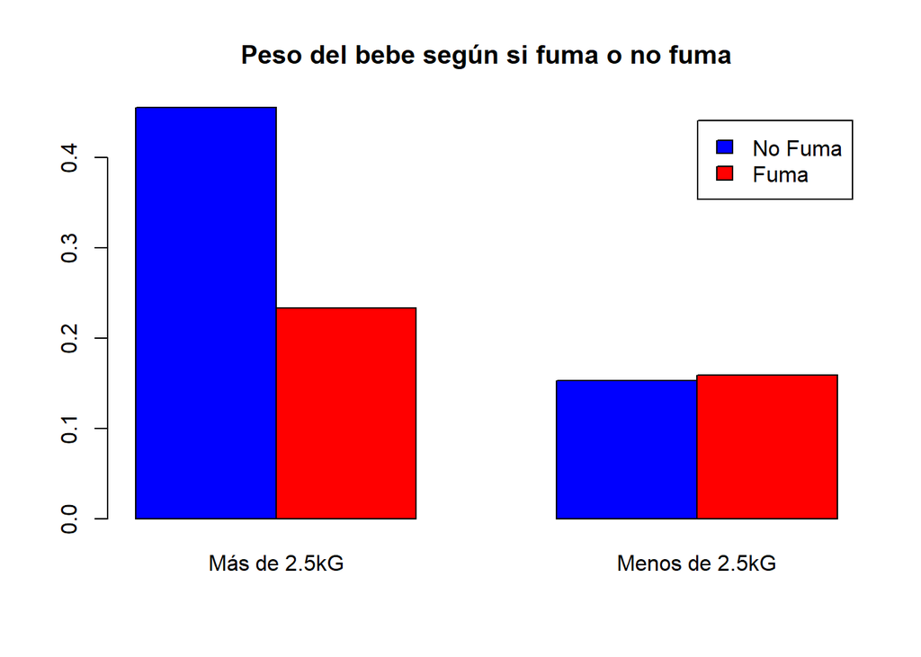

```r
barplot(relacionFumadorNo,main="Peso del bebe según si fuma o no fuma",col=c("Blue","Red"),beside = TRUE,legend.text = TRUE)
```

```r
relacionHipertensa=round(prop.table(table(birthwt$ht,birthwt$low),margin = 1),3)
dimnames(relacionHipertensa)=list(c("No hipertensa","Hipertensa"),c("Mas de 2.5kG","Menos de 2.5kG"))
relacionHipertensa
```

```
##               Mas de 2.5kG Menos de 2.5kG
## No hipertensa        0.706          0.294
## Hipertensa           0.417          0.583
```

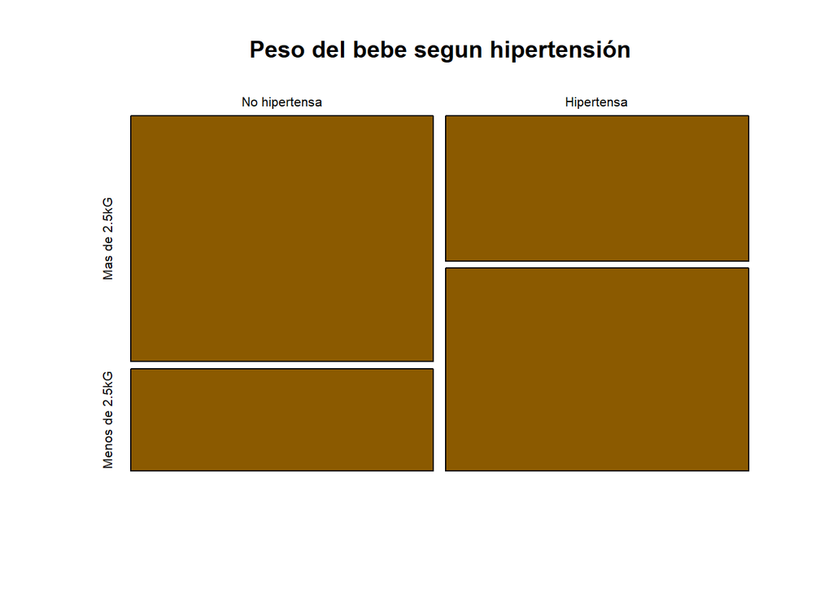

```r
plot(relacionHipertensa,main="Peso del bebe segun hipertensión",col=c("orange4"))
```

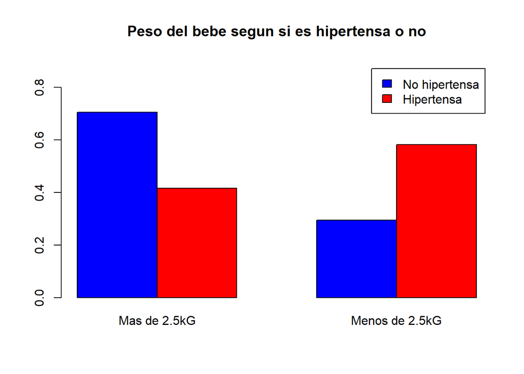

```r
barplot(relacionHipertensa,beside = TRUE,main="Peso del bebe segun si es hipertensa o no",col=c("Blue","Red"),legend.text = TRUE,ylim = c(0,0.9))
```

```r
#INTRUCCION 7
terna=round(prop.table(table(birthwt$race,birthwt$smoke,birthwt$low),margin=3),3)
dimnames(terna)=list(c("Blancos","Negros","Otros"),c("No fuma","Fuma"),c("Más de 2.5kG","Menos de 2.5kG"))
ftable(terna)
```

```
##                  Más de 2.5kG Menos de 2.5kG
##
## Blancos No fuma         0.308          0.068
##         Fuma            0.254          0.322
## Negros  No fuma         0.085          0.085
##         Fuma            0.031          0.102
## Otros   No fuma         0.269          0.339
##         Fuma            0.054          0.085
```

```r
#SEGUN SI FUMA O NO FUMA
relacFumaNegativa=round(prop.table(table(birthwt$race,birthwt$smoke,birthwt$low),margin=2),3)
dimnames(relacFumaNegativa)=list(c("Blancos","Negros","Otros"),c("No fuma","Fuma"),c("Peso mayor a 2.5kG","Peso menor a 2.5kG"))
ftable(relacFumaNegativa)
```

```
##                  Peso mayor a 2.5kG Peso menor a 2.5kG
##
## Blancos No fuma               0.348              0.035
##         Fuma                  0.446              0.257
## Negros  No fuma               0.096              0.043
##         Fuma                  0.054              0.081
## Otros   No fuma               0.304              0.174
##         Fuma                  0.095              0.068
```

```r
##SEGUN LA RAZA DE LA MADRE
razaMother=round(prop.table(table(birthwt$race,birthwt$smoke,birthwt$low),margin = 1),3)
dimnames(razaMother)=list(c("Blancos","Negros","Otros"),c("No fuma","Fuma"),c("Peso mayor a 2.5kG","Peso menor a 2.5kG"))
ftable(razaMother)
```

```
##                  Peso mayor a 2.5kG Peso menor a 2.5kG
##
## Blancos No fuma               0.417              0.042
##         Fuma                  0.344              0.198
## Negros  No fuma               0.423              0.192
##         Fuma                  0.154              0.231
## Otros   No fuma               0.522              0.299
##         Fuma                  0.104              0.075
```

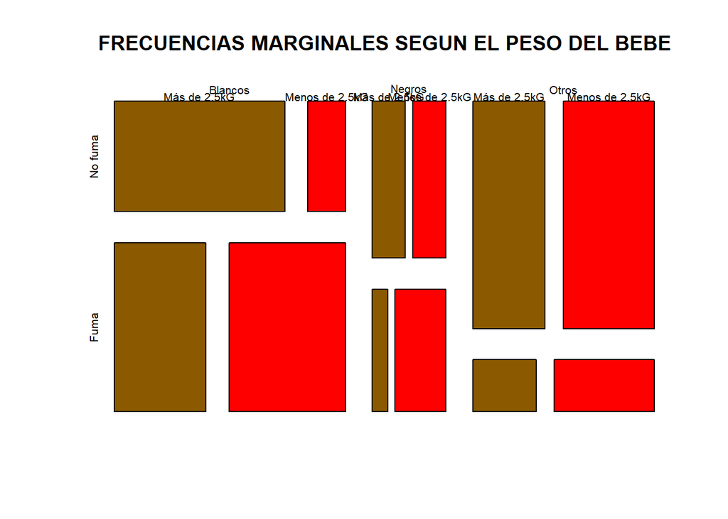

```r
#FRECUENCIAS MARGINALES SEGUN EL PESO DEL BEBE
plot(terna,col=c("orange4","red"),main="FRECUENCIAS MARGINALES SEGUN EL PESO DEL BEBE")
```

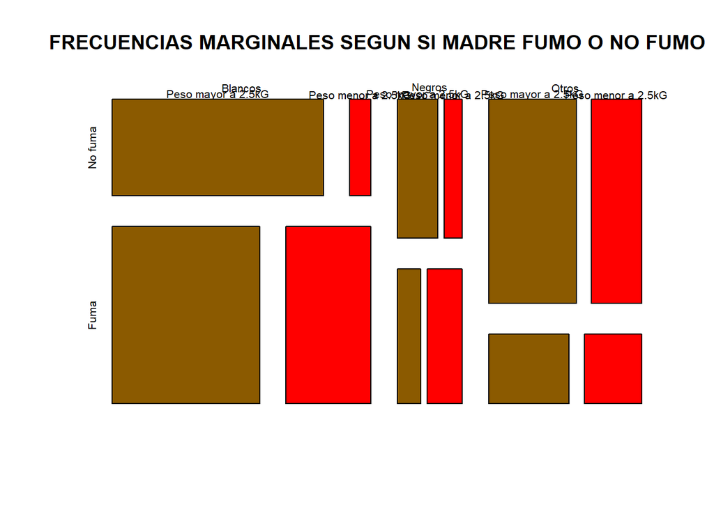

```r
#FRECUENCIAS MARGINALES SEGUN SI LA MADRE FUMÓ DURANTE EL EMBARAZO
plot(relacFumaNegativa,col=c("orange4","red"),main="FRECUENCIAS MARGINALES SEGUN SI MADRE FUMO O NO FUMO")
```

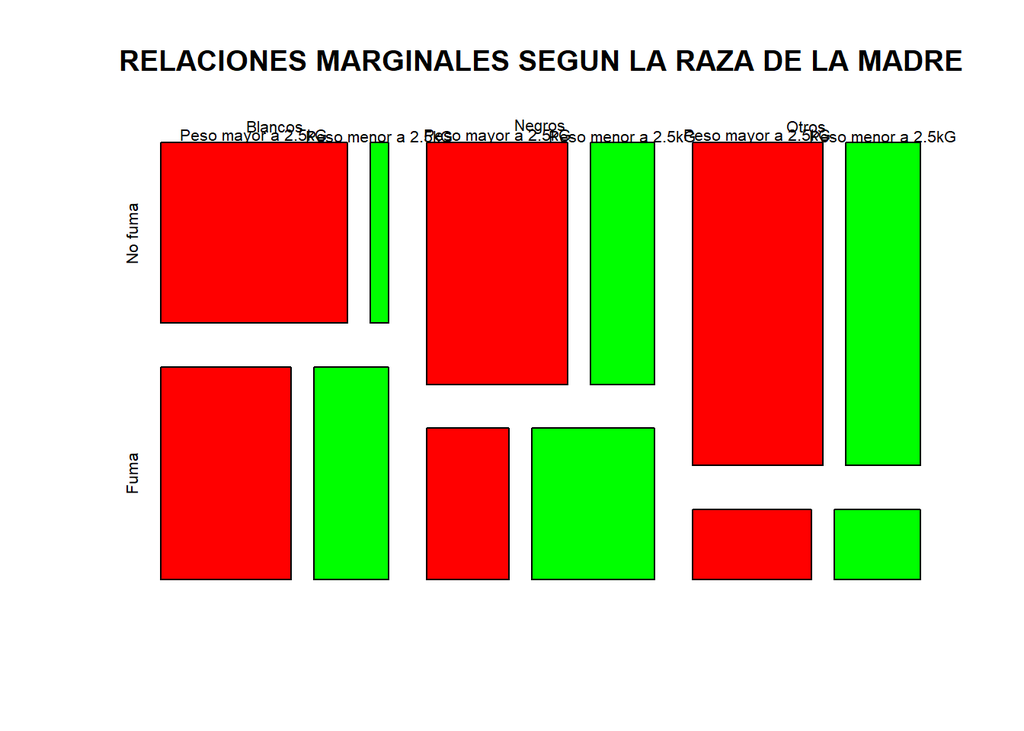

```r
#FRECUENCIAS RELATIVAS
plot(razaMother,col=c("red","green"),main="RELACIONES MARGINALES SEGUN LA RAZA DE LA MADRE")
```